# CONNECT Program Matching

University of Houston, Spring 2022

Ethan Tenison (RGK Center for Philanthropy and Community Service)https://rgkcenter.org/  
December 05, 2021

Every semester the CONNECT Program pairs community organizations with graduate students with data and evaluation skills. As the program has expanded, the matching process has become more complicated, necessitating improved program efficiency. The following document outlines how survey data is taken from Qualtrics, cleaned and sorted, and then matched using the Gale-Shapley Algorithm. Some descriptive data visualizations were included as well to give program managers a snap shot of the semester cohort.

# Projects

### Project Descriptions

Each project is unique, and some are more complex than others. When you are evaluating who should be placed with what organizations, it’s important to keep in my the project goals and deliverables, even if they end up changing. The table below was pulled directly from the organization surveys, and it outlines the project goals, deliverables, and extra considerations.

```r
org <- read_csv("data/raw/CONNECT_organization_spring2022.csv") |>
  select(-c(1:17)) |>
  filter(!row_number() %in% c(2)) |>
  janitor::row_to_names(1) |>
  clean_names() |>
  rename_with(~ gsub('please_rate_how_relevant_the_following_technical_skills_are_to_your_project_', '', .x)) |>
  rename(nonprofit_experience = "how_much_experience_working_or_volunteering_with_nonprofits_should_your_candidate_have_working_or_volunteering_for_nonprofits",
             time_commitment = realistically_how_much_time_do_you_expect_your_student_to_commit_per_week_working_on_your_assigned_project,
    transportation = does_your_candidate_need_to_have_access_to_transportation,
    flexible_hours = will_your_project_permit_flexible_work_hours,
    remote = will_your_candidate_be_able_to_work_remotely) |>
  filter(which_connect_program_is_this_project_affiliated_with == "Hobby School") # Change this depending on school

#write.csv(org, "data/processed/utd_spring_2022.csv", row.names = FALSE)

proj_des <- org |>
  select(
    project_name,
    project_goal,
    project_deliverables,
    what_other_relevant_skills_would_be_helpful_for_your_candidate_to_have_i_e_other_languages_spoken_coding_analytical_software_professional_skills_etc_list_them_here
  ) |>
  rename(
    Project = project_name,
    Goal = project_goal,
    Deliverables = project_deliverables,
    "Other Considerations" = what_other_relevant_skills_would_be_helpful_for_your_candidate_to_have_i_e_other_languages_spoken_coding_analytical_software_professional_skills_etc_list_them_here
  ) |>
  arrange(Project) |>
  mutate(`Other Considerations` = replace_na(`Other Considerations`, ""),
         Deliverables = gsub('(\\s\\d)\\)', '<br><br>\\1\\.', Deliverables))


kbl(proj_des, escape = F) |>
  kable_minimal("hover", full_width = T) |>
  scroll_box(width = "100%", height = "600px")
```

Project

Goal

Deliverables

Other Considerations

American Youthworks - Clean & Green Program

To convey the effectiveness and impact of American YouthWorks’ Clean and Green program to municipal and state government officials, as well as other legislative bodies, to gain financial support and buy-in for replicating the program in other municipalities.

1. Conduct research (e.g. literature review, stakeholder interviews, etc.) on best practices to define key short- and long-term outcomes and metrics with special attention to relevant environmental, work force and justice system metrics;  
   2. Develop a data collection framework â€“ matrix of recommendations outlining metrics/variables for measuring outcomes defined in deliverable #1, baseline data targets (if available), data collection method(s), data collection frequency;  
   3. Design a survey or data collection tool to measure short-term outcomes; and  
   4. Work collaboratively with other CONNECT fellow working with AYW’s HEAT (Houston Environmental Action Team) program to identify areas of opportunity for collaborative or complementary work between the HEAT and Clean and Green program and ways to effectively implement them with community partners

occasional in-person site visits may be needed for the working environment

American Youthworks - HEAT Program

To convey the effectiveness and impact of American YouthWorks’ Houston Environmental Action Team (HEAT) program to municipal and state government officials, as well as other legislative bodies, to gain financial support and buy-in for replicating the program in other municipalities.

1. Conduct research (e.g. literature review, stakeholder interviews, etc.) on best practices to define key short- and long-term outcomes and metrics with special attention to relevant environmental, community involvement and social equity metrics;  
   2. Develop a data collection framework â€“ matrix of recommendations outlining metrics/variables for measuring outcomes defined in deliverable #1, baseline data targets (if available), data collection method(s), data collection frequency;  
   3. Design a survey or data collection tool to measure short-term outcomes; and  
   4. Work collaboratively other CONNECT fellow working with AYW’s Clean and Green program to identify areas of opportunity for collaborative or complementary work between the HEAT and Clean and Green program and ways to effectively implement them with community partners

occasional in-person site visits may be needed for the working environment

Nature Discovery Center

To develop methodologies and tools for counting park visitors and collecting information about park use for the Nature Discovery Center.

1. Methodology for more accurately determining count of park visitors (taking into account how the Nature Discovery Center could leverage its large number of volunteers);  
   2. Data collection tool(s) (e.g. survey, focus groups) that collect information about: park use and activities, guest demographics, and COVID-19; and  
   3. Focus group interview protocol (optional)

### Organization Data

Ordinal questions for both student and organization surveys were converted to a numeric scale. For example, for the question “How much working or volunteering with nonprofits should your candidate have?” the responses were converted from 1 to 5, with “No experience required” being 1 and “2 or more years” being 5. This is done because the algorithm can only compare numeric values.

```r
org_mapping <- org |>
  select(organization,
        organization_address,
        organization_website
        )

org2 <- org |>
  select(
    organization,
    project_name,
    project_goal,
    project_deliverables,
    transportation,
    flexible_hours,
    remote,
    time_commitment,
    nonprofit_experience,
    23:47
  ) |>
  mutate(
    nonprofit_experience = case_when(
      nonprofit_experience == "No experience required" ~ "1",
      nonprofit_experience == "Less than 6 months" ~ "2",
      nonprofit_experience == "6 - 12 months" ~ "3",
      nonprofit_experience == "1 - 2 years" ~ "4",
      nonprofit_experience == "2 or more years" ~ "5",
      TRUE ~ nonprofit_experience
    ),
    time_commitment = case_when(
      time_commitment == "Less than 5 hours per week" ~ "1",
      time_commitment == "5 - 10 hours per week" ~ "2",
      time_commitment == "8 - 12 hours per week" ~ "3",
      time_commitment == "10 - 15 hours per week" ~ "4",
      time_commitment == "15 - 20 hours per week" ~ "5"
    )
  ) |>
  arrange(project_name) |>
  mutate(across(9:34,~gsub("1 - Not relevant", "1", .)),
         across(9:34,~gsub("5 - Extremely relevant", "5", .)),
         across(8:34, as.numeric))


#For Table
org_table <- org2 |>
  select(-c(organization, project_deliverables, project_goal))

names(org_table) <- gsub(pattern = "_",
                         replacement = " ",
                         x = names(org_table))

names(org_table) <- str_to_title(names(org_table))

cell_color <- function(x) {
  x = cell_spec(x,
                color = spec_color(x, end = .7),
                bold = T,)
}

org_table <- org_table |>
  select(-Transportation, -`Flexible Hours`,-Remote, everything()) |>
  mutate(across(2:28, cell_color))

kbl(org_table, escape = F) |>
  kable_material(c("hover", "striped", "condensed"), full_width = F) |>
  scroll_box(width = "100%", height = "300px")
```

| Project Name | Time Commitment | Nonprofit Experience | Tableau | Literature Review | Conducting Interviews | Program Evaluation | Logic Modeling | Html | Arc Gis | Outcomes Definition | Microsoft Office Suite | Google Data Studio | R Shiny | Statistical Analysis | Consulting | Baseline Data Identification | Machine Learning | Project Management | Survey Design | Sql | R | Javascript | Data Mining | Java | Python | Css | Power Bi | Transportation | Flexible Hours | … |
| --- | --- | --- | --- | --- | --- | --- | --- | --- | --- | --- | --- | --- | --- | --- | --- | --- | --- | --- | --- | --- | --- | --- | --- | --- | --- | --- | --- | --- | --- | --- |
| American Youthworks - Clean & Green Program | 2 | 3 | 1 | 5 | 3 | 3 | 1 | 1 | 1 | 5 | 1 | 1 | 1 | 1 | 1 | 1 | 1 | 2 | 5 | 1 | 1 | 1 | 1 | 1 | 1 | 1 | 1 | Yes | Yes | … |
| American Youthworks - HEAT Program | 2 | 3 | 1 | 5 | 3 | 3 | 1 | 1 | 1 | 5 | 1 | 1 | 1 | 1 | 1 | 1 | 1 | 2 | 5 | 1 | 1 | 1 | 1 | 1 | 1 | 1 | 1 | Yes | Yes | … |
| Nature Discovery Center | 2 | 3 | 1 | 5 | 5 | 1 | 1 | 1 | 1 | 1 | 1 | 1 | 1 | 1 | 1 | 1 | 1 | 1 | 5 | 1 | 1 | 1 | 1 | 1 | 1 | 1 | 1 | Yes | Yes | … |

### Project Buckets

There were 3 projects, but some of them involve multiple buckets. Of note, this semester there were zero web design projects. Projects that were continuations from previous semester, or were pre-matched were also not included.

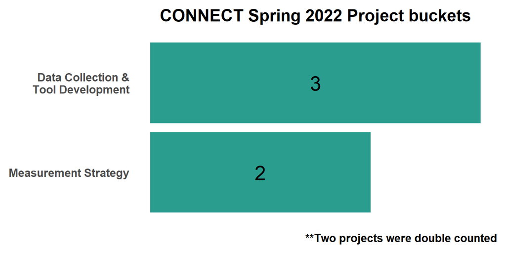

```r
buckets <- org |>
  select(
    organization,
    identify_the_categories_your_project_falls_under_check_all_that_apply
  ) |>
  rename(bucket = identify_the_categories_your_project_falls_under_check_all_that_apply) |>
  group_by(bucket) |>
  count() |>
  ungroup() |>
  add_row(bucket = "Measurement Strategy", n = 2) |>
  mutate(
    n = as.numeric(n),
    ### Just for RGK THIS ROUND because of duplicates
    n = case_when(
      bucket == "Data Collection & Tool Development" ~ n + 2,
      TRUE ~ n
    ),
    bucket = case_when(
      bucket == "Data Collection & Tool Development" ~ "Data Collection &\n Tool Development",
      bucket == "Data Interpretation & Analysis" ~ "Data Interpretation &\n Analysis",
      bucket == "Business Intelligence & Advanced Analytics" ~ "Business Intelligence &\n Advanced Analytics",
      TRUE ~ bucket
    )
  ) |>
  arrange(n) |>
  filter(bucket != "Measurement Strategy,Data Collection & Tool Development")


theme_set(theme_classic())

g <- ggplot(buckets, aes(x = reorder(bucket, n), y = n)) +
  geom_bar(stat = "identity", fill = "#2A9D8F") +
    geom_text(aes(label = n, y = n),
    position = position_stack(vjust = 0.5),
    size = 8) +
  coord_flip()+
   theme(
    panel.grid.major = element_blank(),
    panel.grid.minor = element_blank(),
    axis.line = element_blank(),
     text = element_text(
                         size = 16,
                         face = "bold"),
     axis.title.x = element_blank(),
     axis.title.y = element_blank(),
     axis.ticks = element_blank(),
      axis.text.x=element_blank(),
     plot.title = element_text(hjust = 0.5),
     plot.margin = margin(10, 10, 10, 10),
     legend.title = element_blank(),
     legend.position = "none",

   ) +
  labs(title = "CONNECT Spring 2022 Project buckets",
       y = "Number",
       fill = "Buckets",
       caption = "**Two projects were double counted")


g
```

### Organization Location

```r
library(ggmap)
library(leaflet)
register_google(Sys.getenv("google_geocode_key"))

geo_o <- org |>
  filter(which_connect_program_is_this_project_affiliated_with == "Hobby School") |>
  select(organization, organization_address) |>
  mutate(organization_address = case_when(
    organization_address == "N/A" ~ "",
    TRUE ~ organization_address
  )) |>
  distinct(organization_address, .keep_all = TRUE) |>
  mutate_geocode(organization_address)

# create leaflet map
org_map <- leaflet(geo_o) %>%
  addTiles() %>%
  addMarkers(lng = ~ lon,
             lat = ~ lat,
             popup = ~ organization)

org_map
```

[interactive chart not shown]

### Project Wordcloud

Project CONNECT continues to offer a diverse set of projects to students. The word cloud below shows the most common words located in the project deliverable section. What’s clear about this cohort is that data is king, and we a wide variety of projects and deliverables.

```r
library(wordcloud)
library(RColorBrewer)
library(tm) # to create corpus
library(wordcloud2)
library(htmlwidgets)


# Create a vector containing only the text
text <- org$project_deliverables

# Create a corpus
docs <- Corpus(VectorSource(text))

# standardize corpus
docs <- docs %>%
  tm_map(removeNumbers) %>%
  tm_map(removePunctuation) %>%
  tm_map(stripWhitespace)
docs <- tm_map(docs, content_transformer(tolower))
docs <- tm_map(docs, removeWords, stopwords("english"))

# create a document matrix
dtm <- TermDocumentMatrix(docs)
matrix <- as.matrix(dtm)
words <- sort(rowSums(matrix), decreasing = TRUE)
df <- data.frame(word = names(words), freq = words)
df$word <- as.character(df$word)
target <- c("also", "project", "really", "helpful", "able", "helped", "felt", "wasnt", "etc", "asks", "move", "gave")
"%ni%" <- Negate("%in%")
df <- filter(df, word %ni% target)
df$word <- as.factor(df$word)

set.seed(27)


w1 <-
  wordcloud2(data = df,
             shuffle = FALSE)


w1
```

[interactive chart not shown]

# Students

### Student Data

Because CONNECT uses a formalized survey structure, the data cleaning process for student and organization survey data is virtually the same. The table below includes student skills and experience ratings as well as answers from logistics questions.

```r
stu <- read_csv("data/raw/CONNECT Student (Spring 2022) - UH.csv") |>
  select(-c(1:17)) |>
  filter(!row_number() %in% c(2)) |>
  janitor::row_to_names(1) |>
  clean_names() |>
  rename(pronouns = preferred_pronouns_selected_choice,
         phone = phone_number_please_do_not_include_hyphens_or_parentheses,
         relevant_skills = do_you_have_other_relevant_skills_that_may_be_helpful_for_us_to_know_about_i_e_other_languages_spoken_list_them_here_note_separate_each_skill_with_a_comma,
         target_population = every_semester_the_connect_program_works_with_organizations_that_serve_many_different_target_populations_are_there_any_specific_populations_that_youre_interested_in_working_with,
         nonprofit_experience = over_the_past_5_years_approximately_how_much_experience_have_you_had_working_or_directly_volunteering_with_nonprofit_organizations,
         schools = which_uh_schools_colleges_are_you_affiliated_with_check_all_that_apply_selected_choice,
         schools_other = which_uh_schools_colleges_are_you_affiliated_with_check_all_that_apply_other_please_specify_text,
         international = to_comply_with_university_rules_and_regulations_please_indicate_if_you_are_an_international_student_please_note_that_this_does_not_prohibit_participation_in_this_program) |>
  rename_with(~ gsub('please_rate_your_experience_on_the_following_skills_note_1_not_experienced_and_5_extremely_experienced_', '', .x))


stu4 <- stu |>
  select(
    first_name,
    last_name,
    is_there_any_additional_information_regarding_your_availability_that_we_should_know_about,
    do_you_have_access_to_transportation,
    do_you_need_flexible_work_hours,
    do_you_need_the_ability_to_work_remotely,
    nonprofit_experience,
    realistically_how_much_time_can_you_commit_per_week_to_working_on_a_project,
    26:52
  ) |>
    rename(
      time_commitment = realistically_how_much_time_can_you_commit_per_week_to_working_on_a_project,
      transportation = do_you_have_access_to_transportation,
      flexible_hours = do_you_need_flexible_work_hours,
      remote = do_you_need_the_ability_to_work_remotely,
      microsoft_office_suite = microsoft_office) |>
  mutate(nonprofit_experience = case_when(
    nonprofit_experience == "No experience (yet!)" ~ "1",
    nonprofit_experience == "Less than 6 months" ~ "2",
    nonprofit_experience == "6 - 12 months" ~ "3",
    nonprofit_experience == "1 - 2 years" ~ "4",
    nonprofit_experience == "2 or more years" ~ "5",
    TRUE ~ "1"
  ),
  time_commitment = case_when(
    time_commitment == "Less than 5 hours per week" ~ "1",
    time_commitment == "5-10 hours per week" ~ "2",
    time_commitment == "8-12 hours per week" ~ "3",
    time_commitment == "10-15 hours per week" ~ "4",
    time_commitment == "15-20 hours per week" ~ "5"

  )) |>
  mutate(
        across(9:33,~gsub("1-Not Experienced", "1", .)),
         across(9:33,~gsub("5-Extremely Experienced", "5", .)),
         across(9:33, as.numeric),
         name = paste0(first_name," ", last_name))

stumas <- stu4

stu4 <- stu4 |>
  select(name, time_commitment, 4:35) |>
  arrange(str_extract(name,'\\s.*$')) |>
  mutate(nonprofit_experience = as.numeric(nonprofit_experience),
         time_commitment = as.numeric(time_commitment))


#For table
stu_table <- stu4 |>
  select(-c(relevant_skills, target_population))

names(stu_table) <- gsub(pattern = "_",
                  replacement = " ",
                  x = names(stu_table))

names(stu_table) <- str_to_title(names(stu_table))


cell_color <- function(x) {
  x = cell_spec(x,
                color = spec_color(x, end = .7),
                bold = T,
                )
}

stu_table <- stu_table |>
  select(-Transportation,-`Flexible Hours`, -Remote, everything()) |>
  mutate(across(2:28, cell_color))


kbl(stu_table, escape = F) |>
  kable_material(c("hover", "striped", "condensed"), full_width = F) |>
  scroll_box(width = "100%", height = "400px")
```

| Name | Time Commitment | Nonprofit Experience | Literature Review | Program Evaluation | Consulting | Project Management | Baseline Data Identification | Logic Modeling | Outcomes Definition | Survey Design | Conducting Interviews | Data Mining | Statistical Analysis | Sql | Machine Learning | Html | Css | Java | Python | Tableau | Microsoft Office Suite | R | R Shiny | Arc Gis | Power Bi | Google Data Studio | Javascript | Transportation | Flexible Hours | … |
| --- | --- | --- | --- | --- | --- | --- | --- | --- | --- | --- | --- | --- | --- | --- | --- | --- | --- | --- | --- | --- | --- | --- | --- | --- | --- | --- | --- | --- | --- | --- |
| Sayali Chaudhari | 2 | 2 | 4 | 4 | 4 | 4 | 4 | 4 | 4 | 4 | 4 | 3 | 4 | 1 | 4 | 2 | 1 | 1 | 4 | 1 | 4 | 3 | 1 | 4 | 1 | 1 | 1 | Yes | Yes | … |
| Vesali Ellango | 5 | 1 | 3 | 4 | 5 | 4 | 3 | 2 | 2 | 3 | 4 | 2 | 3 | 3 | 3 | 4 | 4 | 3 | 3 | 1 | 5 | 4 | 1 | 1 | 3 | 1 | 4 | Yes | Yes | … |
| Madhavi Etaveni | 5 | 5 | 3 | 3 | 4 | 4 | 3 | 3 | 4 | 4 | 4 | 3 | 3 | 3 | 2 | 3 | 2 | 1 | 2 | 1 | 4 | 1 | 1 | 2 | 1 | 2 | 1 | Yes | No | … |
| Alexia Frometa | 2 | 5 | 3 | 2 | 2 | 4 | 2 | 1 | 1 | 2 | 5 | 1 | 1 | 1 | 1 | 1 | 1 | 1 | 1 | 1 | 5 | 1 | 1 | 1 | 1 | 1 | 1 | Yes | Yes | … |
| Ashley Gelato | 5 | 5 | 4 | 3 | 2 | 2 | 2 | 1 | 1 | 1 | 3 | 2 | 2 | 1 | 1 | 1 | 1 | 1 | 1 | 1 | 3 | 2 | 2 | 1 | 2 | 2 | 1 | Yes | Yes | … |
| Karen Hernandez | 5 | 1 | 3 | 2 | 1 | 1 | 3 | 3 | 3 | 1 | 1 | 1 | 3 | 1 | 1 | 1 | 1 | 2 | 1 | 1 | 5 | 1 | 1 | 1 | 1 | 1 | 2 | Yes | Yes | … |
| KRISHNAVENI KATTA | 4 | 5 | 3 | 3 | 3 | 3 | 3 | 2 | 3 | 3 | 2 | 3 | 3 | 2 | 2 | 2 | 2 | 1 | 2 | 1 | 3 | 2 | 1 | 1 | 1 | 1 | 1 | No | Yes | … |
| Ranjith Kumar Reddy Gouni | 5 | 5 | 1 | 2 | 3 | 4 | 2 | 1 | 2 | 1 | 3 | 1 | 2 | 1 | 1 | 1 | 1 | 1 | 3 | 1 | 5 | 1 | 1 | 1 | 1 | 1 | 1 | Yes | Yes | … |
| Elizabeth Lakas | 3 | 2 | 2 | 1 | 1 | 1 | 1 | 2 | 1 | 3 | 1 | 1 | 3 | 1 | 2 | 2 | 1 | 1 | 1 | 1 | 5 | 1 | 1 | 1 | 1 | 1 | 1 | Yes | No | … |
| Alison LiVecchi | 5 | 1 | 3 | 2 | 3 | 4 | 3 | 4 | 3 | 1 | 2 | 2 | 4 | 1 | 1 | 1 | 1 | 1 | 1 | 1 | 3 | 1 | 1 | 1 | 1 | 1 | 1 | Yes | No | … |
| Andrew Marks | 5 | 1 | 3 | 1 | 1 | 1 | 1 | 1 | 1 | 1 | 1 | 1 | 2 | 1 | 1 | 1 | 1 | 1 | 1 | 1 | 3 | 1 | 1 | 1 | 1 | 1 | 1 | Yes | Yes | … |
| Duc Nguyen | 3 | 2 | 5 | 4 | 4 | 4 | 4 | 4 | 4 | 5 | 4 | 4 | 4 | 1 | 1 | 1 | 1 | 1 | 1 | 1 | 4 | 1 | 1 | 1 | 1 | 1 | 1 | Yes | Yes | … |
| ESNEIDER PESCA | 5 | 5 | 3 | 4 | 4 | 4 | 5 | 5 | 3 | 5 | 4 | 4 | 5 | 3 | 3 | 3 | 3 | 3 | 3 | 3 | 5 | 3 | 3 | 3 | 3 | 3 | 3 | Yes | Yes | … |
| Rome Street | 2 | 5 | 2 | 3 | 4 | 4 | 2 | 2 | 2 | 3 | 4 | 1 | 1 | 1 | 1 | 2 | 1 | 1 | 1 | 1 | 5 | 1 | 1 | 1 | 1 | 1 | 1 | Yes | Yes | … |
| Mustafa Syed | 5 | 2 | 1 | 2 | 1 | 5 | 1 | 1 | 2 | 2 | 2 | 1 | 1 | 1 | 1 | 1 | 1 | 1 | 1 | 1 | 4 | 1 | 1 | 1 | 1 | 1 | 1 | Yes | No | … |
| Bridget Wallenberger | 3 | 1 | 4 | 3 | 3 | 3 | 3 | 3 | 3 | 3 | 3 | 3 | 4 | 3 | 3 | 5 | 3 | 3 | 3 | 3 | 5 | 3 | 3 | 3 | 3 | 3 | 3 | Yes | No | … |
| Sarah Webb | 2 | 1 | 3 | 2 | 1 | 4 | 3 | 2 | 2 | 3 | 4 | 1 | 3 | 1 | 1 | 1 | 1 | 1 | 1 | 1 | 5 | 1 | 1 | 1 | 2 | 1 | 1 | Yes | Yes | … |
| Kacey Williams | 4 | 1 | 1 | 1 | 1 | 1 | 1 | 1 | 1 | 1 | 1 | 1 | 2 | 1 | 1 | 2 | 1 | 1 | 1 | 1 | 4 | 1 | 4 | 1 | 1 | 1 | 1 | Yes | Yes | … |
| Jessica Zeigler | 4 | 5 | 1 | 1 | 1 | 1 | 1 | 1 | 1 | 1 | 2 | 1 | 1 | 2 | 1 | 2 | 1 | 1 | 1 | 1 | 5 | 1 | 1 | 1 | 1 | 1 | 1 | Yes | Yes | … |

**Overall, 19 students applied during this cohort.**

### Student Location

We do not collect student addresses, but `Qualtrics` does record the longitude and latitude of where students fill out the form. Therefore, the following map is only an estimate of where our applicants live.

```r
stu_geo <- read_csv("data/raw/CONNECT Student (Spring 2022) - UH.csv") |>
  filter(!row_number() %in% c(2)) |>
  janitor::row_to_names(1) |>
  clean_names() |>
  select(first_name, last_name, location_latitude, location_longitude ) |>
  mutate(name = paste0(first_name, " ",last_name),
         location_latitude = as.numeric(location_latitude),
         location_longitude = as.numeric(location_longitude))


# create leaflet map
stu_map <- leaflet(stu_geo) %>%
  addTiles() %>%
  addMarkers(lng = ~location_longitude,
             lat = ~location_latitude,
             popup = ~ name)

stu_map
```

[interactive chart not shown]

### Other student information

The following table includes students’ responses to open ended questions. It’s impossible to list every single skill that might be relevant for a project on the survey (although we have tried), so the relevant skills question is attempt to fill that gap. In addition, for the first time a question about target population was added to the survey. This came out of our diversity, equity, and inclusion evaluation that was conducted during our summer cohort. Students voiced their desire to specify which populations they are most interested in. As an open ended question, we can not use target population in the algorithm in its present state. However, we will have the opportunity to improve the question methodology in subsequent cohorts to give students more of a say in the organizations they work with.

```r
stu_table2 <- stumas |>
  select(name, relevant_skills, target_population, is_there_any_additional_information_regarding_your_availability_that_we_should_know_about) |>
  rename(additional_information = is_there_any_additional_information_regarding_your_availability_that_we_should_know_about) |>
  mutate(relevant_skills = replace_na(relevant_skills, ""),
         target_population = replace_na(target_population, ""),
         additional_information = replace_na(additional_information, ""))

names(stu_table2) <- gsub(pattern = "_",
                  replacement = " ",
                  x = names(stu_table2))

names(stu_table2) <- str_to_title(names(stu_table2))

kbl(stu_table2, escape = F) |>
  kable_minimal(c("hover"), full_width = F) |>
  scroll_box(width = "100%", height = "400px")
```

| Name | Relevant Skills | Target Population | Additional Information |
| --- | --- | --- | --- |
| Ashley Gelato | I am conversational in Spanish but read and write at the intermediate level, I have a combined Humanities and Digital background from my undergrad and now in my master’s. I have knowledge of how to us… | I am open to working with anyone. | I am applying for work, but if I receive a paid opportunity I will likely choose to remain in the CONNECT program instead. However, in the Summer if I am offered a fellowship opportunity by the govern… |
| Andrew Marks |  |  |  |
| ESNEIDER PESCA | native Spanish | Minors | no |
| Karen Hernandez | Bilingual | Hispanic/Latinos |  |
| Bridget Wallenberger | I work well with others, and eager to learn. | I am open to anything. |  |
| Alexia Frometa |  | adolescents and young adults; schools |  |
| Rome Street | Spanish, Political Consulting Experience, Volunteer Experience | Veterans, Children, Adults, Women |  |
| Sarah Webb |  |  |  |
| Duc Nguyen | Vietnamese, Chinese, French, Rstudio, Stata |  |  |
| Alison LiVecchi | STATA, designing trainings, presenting workshops to groups ranging from 5-500 | I am interested in education policy, but am open to learning about other areas as well. | I am working full-time until Feb 1. |
| Kacey Williams |  |  |  |
| Madhavi Etaveni |  |  |  |
| Ranjith Kumar Reddy Gouni |  |  | Monday: 6 pm to 7:30 pm, Tuesday: 2:30 pm to 4 pm, Friday: 10:00 am to 11:30 am; these days are my class timings, I’m available other than this timings. |
| Mustafa Syed | Urdu | Never mind | I have experienced in Construction |
| Vesali Ellango |  |  | I’m a graduate student and have classes 3 times a week during the evenings |
| Elizabeth Lakas | Fluent in Spanish, Civil Engineer | No, I am open to anything | I am an international student |
| Sayali Chaudhari |  |  |  |
| KRISHNAVENI KATTA |  |  |  |
| Jessica Zeigler |  | LGBTQ+ communities, formerly or currently incarcerated people, migrants, sex workers, people seeking abortions or reproductive healthcare, people with dementia, domestic violence survivors, neurodiver… | Will be participating in a study abroad trip to India from March 11-26 |

### Student Skills

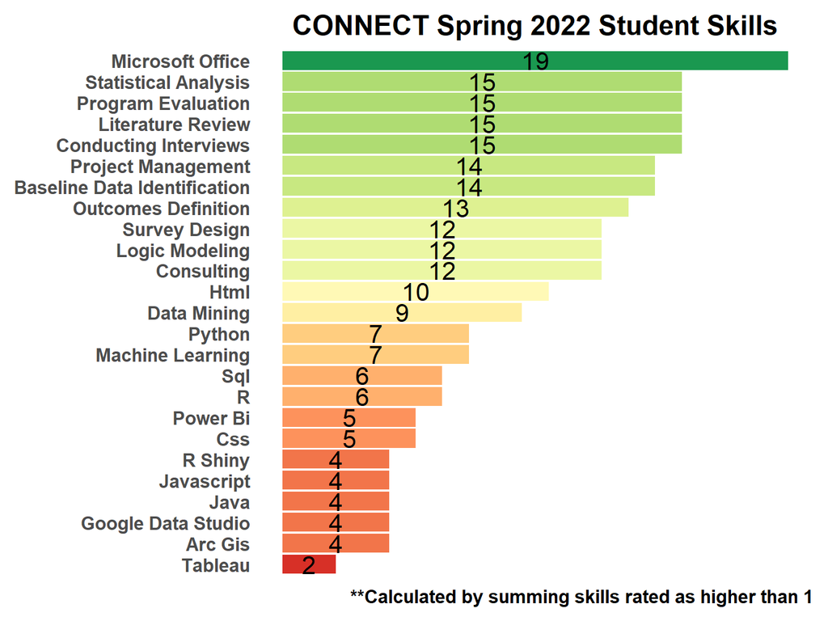

```r
stu2 <- stu |>
  select(first_name, 26:50)

names(stu2) <- gsub(pattern = "_",
                   replacement = " ",
                   x = names(stu2))

names(stu2) <- str_to_title(names(stu2))

stu3 <- stu2 |>
  mutate(
    across(2:26,~gsub("1-Not Experienced", "1", .)),
         across(2:26,~gsub("5-Extremely Experienced", "5", .)),
         across(2:26, as.numeric)
  ) |>
  pivot_longer(col = 2:26,
               names_to = "Skill",
               values_to = "Rating") |>
  #Setting students who put 1 to NA
  mutate(Rating = na_if(Rating, 1)) |>
  drop_na() |>
  group_by(Skill) |>
  count()

theme_set(theme_classic())

g <- ggplot(stu3, aes(x = reorder(Skill, n), y = n, fill = n)) +
  geom_bar(stat = "identity") +
  geom_text(aes(label = n, y = n),
            position = position_stack(vjust = 0.5),
            size = 6) +
  coord_flip() +
  theme(
    panel.grid.major = element_blank(),
    panel.grid.minor = element_blank(),
    axis.line = element_blank(),
    text = element_text(size = 16,
                        face = "bold"),
    axis.title.x = element_blank(),
    axis.title.y = element_blank(),
    axis.ticks = element_blank(),
    axis.text.x = element_blank(),
    plot.title = element_text(hjust = 0.5),
    plot.margin = margin(10, 10, 10, 10),
    legend.title = element_blank(),
    legend.position = "none"

  ) +
  labs(title = "CONNECT Spring 2022 Student Skills",
       caption = "**Calculated by summing skills rated as higher than 1") +
   scale_fill_distiller(palette = "RdYlGn", direction = 1)


g
```

# Matching

In order to use the matching Algorithm, students and organizations have to be assigned a utility ratings. These ratings are formulated by comparing how similar the students’ skills and nonprofit experience are to the project expectations.

Each student receives a utility score for each organization, and each organization is assigned a utility sore for each student. This ensures that both the student’s and organization’s rankings are taken into account for the matching process. For example, if an organization assigns two students the same utility score, but one student has a higher utility score for that organization, this student is selected and the other student returns to the selection pool.

### Utility Score Example

Additionally, if a student put a 1 on a skill, which means they have no background in it, they automatically receive a zero utility rating. Students who don’t match the organization based on the logistics questions, also receive a utility rating of zero.

Finally, all of the skill utility ratings are added up to produce one utility rating for Sayali Chaudhari and American Youthworks. The higher the number, the greater the utility the student will have for that project.

```r
#Initial Data Manipulation
org1 <- org2[1, ] |>
  pivot_longer(9:34, names_to = "variable", values_to = "org_value")
stu1 <- stu4[1, ] |>
  pivot_longer(6:31, names_to = "variable", values_to = "student_value")

#Assigning a utility score for each skill
match1 <- left_join(org1, stu1, by = "variable") |>
  mutate(
    subtracted = student_value - org_value,
    utility = case_when(
      subtracted >= 0 ~ 1,
      subtracted == -1 ~ .75,
      subtracted == -2 ~ .5,
      subtracted == -3 ~ .25,
      subtracted == -4 ~ 0
    ),
    #if the student put 1 on their survey it means
    #they would provide 0 utility for that skills
    utility = case_when(
      student_value == 1 ~ 0,
      TRUE ~ utility),
    #If the students logistics don't match up with the orgs
    #Then the utility for that student changes to 0
    utility = case_when(
      transportation.x == "Yes" & transportation.y == "No" ~ 0,
      flexible_hours.x == "No" & flexible_hours.y == "Yes" ~ 0,
      remote.x == "No" & remote.y == "Yes" ~ 0,
      TRUE ~ utility
    ),#If the orgs time commitment is greater than what the student
    #is willing to work their utility is set to 0
    utility = case_when(
      time_commitment.x > time_commitment.y ~ 0,
      TRUE ~ utility
    )
  )

utility_score <- sum(match1$utility)
print(paste0(stu1[1,1],"'s utility for ",org1[1,1], ": ", utility_score))
```

```
[1] "Sayali Chaudhari's utility for American Youthworks: 17"
```

### Organization Utility Scores

For simplicity sake, only the organization utility scores are shown below because their preference matters more in the event of an unsuitable first match. Higher organization utility scores mean that the student is better suited to the organization’s project. These ratings can be validated by reviewing students resumes when necessary.

```r
#utility organizations
row_names <- stu4$name
column_names <- org2$project_name

uO <- matrix(nrow = length(stu4$name),
             ncol = length(org2$project_name),
             dimnames = list(row_names, column_names))


for (j in 1:length(stu4$name)) {
  for (i in 1:length(org2$project_name)) {
    org1 <- org2[i,] |>
      pivot_longer(9:34, names_to = "variable", values_to = "org_value")

    stu1 <- stu4[j,] |>
      pivot_longer(6:31, names_to = "variable", values_to = "student_value")

    match1 <- left_join(org1, stu1, by = "variable") |>
      mutate(
        subtracted =  org_value - student_value,
        utility = case_when(
          subtracted <= 0 ~ 1,
          subtracted == 1 ~ .75,
          subtracted == 2 ~ .5,
          subtracted == 3 ~ .25,
          subtracted >= 4 ~ 0
        ),
        utility = case_when(
          org_value == 1 ~ 0,
          TRUE ~ utility),
        utility = case_when(
          transportation.x == "Yes" & transportation.y == "No" ~ 0,
          flexible_hours.x == "No" & flexible_hours.y == "Yes" ~ 0,
          remote.x == "No" & remote.y == "Yes" ~ 0,
          TRUE ~ utility
        ),
        utility = case_when(time_commitment.x > time_commitment.y ~ 0,
                            TRUE ~ utility)
      )

    utility_score <- sum(match1$utility)
    uO[j, i] <- utility_score
  }
}

#Table Styling
cell_color <- function(x) {
  x = cell_spec(x,
                color = spec_color(x, end = .7),
                bold = T,
                )
}


uO_table <- as.data.frame(uO) |>
  mutate(across(1:3, cell_color))


kbl(uO_table, escape = F) |>
  kable_material(c("hover", "striped", "condensed"), full_width = F) |>
  scroll_box(width = "100%", height = "400px")
```

|  | American Youthworks - Clean & Green Program | American Youthworks - HEAT Program | Nature Discovery Center |
| --- | --- | --- | --- |
| Sayali Chaudhari | 6 | 6 | 3 |
| Vesali Ellango | 4.75 | 4.75 | 2.25 |
| Madhavi Etaveni | 6 | 6 | 3 |
| Alexia Frometa | 4.5 | 4.5 | 2.75 |
| Ashley Gelato | 4.75 | 4.75 | 2.25 |
| Karen Hernandez | 3.5 | 3.5 | 1 |
| KRISHNAVENI KATTA | 0 | 0 | 0 |
| Ranjith Kumar Reddy Gouni | 4 | 4 | 1.5 |
| Elizabeth Lakas | 3.25 | 3.25 | 1.5 |
| Alison LiVecchi | 4 | 4 | 1.25 |
| Andrew Marks | 2.75 | 2.75 | 1 |
| Duc Nguyen | 6.5 | 6.5 | 3.5 |
| ESNEIDER PESCA | 6 | 6 | 3.25 |
| Rome Street | 5 | 5 | 2.5 |
| Mustafa Syed | 3.75 | 3.75 | 1.25 |
| Bridget Wallenberger | 5.25 | 5.25 | 2.25 |
| Sarah Webb | 4.5 | 4.5 | 2.25 |
| Kacey Williams | 2.25 | 2.25 | 0.5 |
| Jessica Zeigler | 3 | 3 | 1.25 |

### The Gale Shapley Algorithm

```r
#Matching Algorithm
matching = galeShapley.marriageMarket(uS, uO)
```

### Matching Results

The table below shows the matching results. Matches should be validated by reviewing student resumes to ensure they have relevant work experience. The table also shows a list of all the top scorers for each project. Program managers can use this list to help them find a match if the first wasn’t suitable.

```r
#Creating a list of top scorers
uO2 <- as.data.frame(uO)
org_options <- tibble::rownames_to_column(uO2, "Student")
tops <- list()

for (i in 2:ncol(org_options)) {
  org_top <- org_options |>
    slice_max(org_options[,i], n = 3)

tops[[i]] <- paste(org_top$Student, collapse=", ")
}

tops <- tops[-1]
top_df <- data.frame(matrix(unlist(tops), nrow=length(tops), byrow=TRUE))

top_df$matrix.unlist.tops...nrow...length.tops...byrow...TRUE.<-
  gsub("\\."," ",top_df$matrix.unlist.tops...nrow...length.tops...byrow...TRUE.)

#Creating a data frame for table
org_info <- org2 |>
  select(project_name)

students_matched <- stu4 |>
  slice(matching$engagements) |>
  bind_cols(org_info) |>
  bind_cols(top_df) |>
  rename(Student = name,
         Project = project_name,
         "Top Scores" = "matrix.unlist.tops...nrow...length.tops...byrow...TRUE.") |>
  select(Project, Student,"Top Scores")


var_label(students_matched$Project) <- NULL



kbl(students_matched) |>
  kable_material(c("hover","striped"), full_width = F) |>
  scroll_box(width = "100%", height = "400px")
```

| Project | Student | Top Scores |
| --- | --- | --- |
| American Youthworks - Clean & Green Program | Duc Nguyen | Duc Nguyen, Sayali Chaudhari, Madhavi Etaveni, ESNEIDER PESCA |
| American Youthworks - HEAT Program | Madhavi Etaveni | Duc Nguyen, Sayali Chaudhari, Madhavi Etaveni, ESNEIDER PESCA |
| Nature Discovery Center | ESNEIDER PESCA | Duc Nguyen, ESNEIDER PESCA, Sayali Chaudhari, Madhavi Etaveni |

[figure not shown]